# PSet5A

1. The Team
1. Luke Beasley (lcb2165), Chris Russo (cfr2125), Gideon Teitel (gt2288)
2. Chris: I, II, III Swing rates by player Parallel coordinates

Luke: IV- Missing values Heat maps Time series with teams or players Histogram over variables Shiny interactive

Gideon: Most effective pitch sequences Pitch location by bunt opportunties Violin plots/ridgeline etc.

1. How do pinch hitters swing rates compare to non-pinch hitters?
2. Are certain pitch sequences more effective than others?
3. How does a batter’s batting average/scatter chart change based on pitch location?
3. Output: html_document (*plan right now is to create a shiny app as well)

The pitch by pitch Statcast data was gathered from baseballsavant.com via the Search page. We downloaded the data in .csv format. Due to the number of observations, we downloaded the pitches one week at a time. We then combined the data sets into an .rda file that contains all 743,495 pitches from the 2019 season.

The team data was obtained from www.fangraphs.com, a website meant for hobbyists to explore data within baseball. After navigating to teams screen, we chose multiple seasons of data (2010-2019) and checked the “split seasons” button in order to have a different row for every season for each team, as opposed to aggregating each teams data over those years. The export data button downloads this file as a ready to use .csv file that we import after putting into the correct directory.

```r
library(extracat)
library(tidyverse)
```

After loading in the pbp2019 data set that will be used throughout this analysis, we will first examine the missing values. The data set has too many features to make use of a graph, but a few clear trends exist after looking at the column missing values and taking a look at the data. Many variables such as pitcher, batter, strikes, and balls, have no missing values, while others have large amounts. The explanation for this is inuitive: each pitch represents a row of data and the values without missing values are the values that exist no matter the outcome of the pitch. While many of the variables missing many values depend on the outcome of the pitch. A couple examples: launch_angle will not be present if the ball was not hit. on_2b will not be present if no one is on second base.

Interestingly, we see related variables share the same values of missing variables, such as all of the fielder_ variables having a missing value of 3159. The best explanation of this is that some ballparks (games in different countries) may not have measured these variables.

After looking at the colMeans, we see that a few variables are missing for every value in the dataset, so we drop them from the data frame.

```r
load('pbp2019.rda')
pbp2019[pbp2019=='null']<- NA
head(pbp2019,5)
```

```
##   pitch_type game_date release_speed release_pos_x release_pos_z
## 1         FS  4/6/2019          87.3        -2.735        5.3737
## 2         FS  4/6/2019          86.7       -2.8143        5.3996
## 3         FF  4/6/2019          93.3       -2.6833        5.3615
## 4         FF  4/6/2019          93.1       -2.6642         5.576
## 5         FF  4/6/2019          91.5       -2.6197        5.5035
##   player_name batter pitcher    events     description spin_dir
## 1 Kirby Yates 451594  489446 strikeout swinging_strike       NA
## 2 Kirby Yates 451594  489446      <NA>   called_strike       NA
## 3 Kirby Yates 451594  489446      <NA>            ball       NA
## 4 Kirby Yates 451594  489446      <NA>            ball       NA
## 5 Kirby Yates 451594  489446      <NA>   called_strike       NA
##   spin_rate_deprecated break_angle_deprecated break_length_deprecated zone
## 1                   NA                     NA                      NA    7
## 2                   NA                     NA                      NA    9
```

[output cut: 87 more lines]

```r
colSums(is.na(pbp2019)) %>% sort(decreasing=TRUE)
```

```
##                        spin_dir            spin_rate_deprecated
##                          743495                          743495
##          break_angle_deprecated         break_length_deprecated
##                          743495                          743495
##                  tfs_deprecated             tfs_zulu_deprecated
##                          743495                          743495
##                          umpire                           on_3b
##                          743495                          675428
##                            hc_x                            hc_y
##                          616331                          616331
##   estimated_ba_using_speedangle estimated_woba_using_speedangle
##                          615971                          615971
##              launch_speed_angle                         bb_type
##                          615971                          615969
##                           on_2b                    hit_location
##                          607922                          579436
##                      woba_denom                          events
##                          554651                          554648
##                      woba_value                     babip_value
##                          554648                          554648
##                       iso_value                             des
##                          554648                          554644
##                 hit_distance_sc                    launch_speed
##                          547524                          535877
##                    launch_angle                           on_1b
##                          535877                          518670
##               release_spin_rate                 effective_speed
##                           17935                            6230
##                   release_pos_x                   release_pos_z
##                            5070                            5070
##                            zone                           pfx_x
##                            5070                            5070
##                           pfx_z                         plate_x
##                            5070                            5070
##                         plate_z                             vx0
##                            5070                            5070
##                             vy0                             vz0
##                            5070                            5070
##                              ax                              ay
##                            5070                            5070
```

[output cut: 35 more lines]

```
##                               0                               0
##                         game_pk                       pitcher.1
##                               0                               0
##                   at_bat_number                    pitch_number
##                               0                               0
##                      pitch_name                      home_score
##                               0                               0
##                      away_score                       bat_score
##                               0                               0
##                       fld_score                 post_away_score
##                               0                               0
##                 post_home_score                  post_bat_score
##                               0                               0
##                  post_fld_score
##                               0
```

```r
tidy_data <- pbp2019 %>% gather(key='row',value = 'value', -sv_id) %>% mutate(missing= ifelse(is.na(value),'yes','no'))
colMeans(is.na(pbp2019))
```

```
##                      pitch_type                       game_date
##                     0.005912615                     0.000000000
##                   release_speed                   release_pos_x
##                     0.006785520                     0.006819145
##                   release_pos_z                     player_name
##                     0.006819145                     0.000000000
##                          batter                         pitcher
##                     0.000000000                     0.000000000
##                          events                     description
##                     0.746000982                     0.000000000
##                        spin_dir            spin_rate_deprecated
##                     1.000000000                     1.000000000
##          break_angle_deprecated         break_length_deprecated
##                     1.000000000                     1.000000000
##                            zone                             des
##                     0.006819145                     0.745995602
##                       game_type                           stand
##                     0.000000000                     0.000000000
##                        p_throws                       home_team
##                     0.000000000                     0.000000000
##                       away_team                            type
##                     0.000000000                     0.000000000
##                    hit_location                         bb_type
##                     0.779340816                     0.828477663
##                           balls                         strikes
##                     0.000000000                     0.000000000
##                       game_year                           pfx_x
##                     0.000000000                     0.006819145
##                           pfx_z                         plate_x
##                     0.006819145                     0.006819145
##                         plate_z                           on_3b
##                     0.006819145                     0.908449956
##                           on_2b                           on_1b
##                     0.817654456                     0.697610609
##                    outs_when_up                          inning
##                     0.000000000                     0.000000000
##                   inning_topbot                            hc_x
##                     0.000000000                     0.828964553
##                            hc_y                  tfs_deprecated
##                     0.828964553                     1.000000000
```

[output cut: 35 more lines]

```
##                     0.746000982                     0.828480353
##                   at_bat_number                    pitch_number
##                     0.000000000                     0.000000000
##                      pitch_name                      home_score
##                     0.000000000                     0.000000000
##                      away_score                       bat_score
##                     0.000000000                     0.000000000
##                       fld_score                 post_away_score
##                     0.000000000                     0.000000000
##                 post_home_score                  post_bat_score
##                     0.000000000                     0.000000000
##                  post_fld_score           if_fielding_alignment
##                     0.000000000                     0.006555525
##           of_fielding_alignment
##                     0.006555525
```

```r
drop <- c('spin_dir', 'spin_rate_deprecated','break_angle_deprecated','break_length_deprecated','tfs_deprecated','tfs_zulu_deprecated','umpire')
pbp2019 <- pbp2019[,!(names(pbp2019) %in% drop)]
```

```r
# read in season data frame
season_data <- read.csv('FanGraphs_Leaderboard.csv')
head(season_data,10)
```

```
##    ï..Season      Team    G   PA  HR   R RBI  SB    BB.     K.   ISO BABIP
## 1       2019    Astros 2309 6394 288 920 891  67 10.1 % 18.2 % 0.221 0.296
## 2       2016      Cubs 2332 6335 199 808 767  66 10.4 % 21.1 % 0.173 0.302
## 3       2011   Yankees 2301 6306 222 867 836 147  9.9 % 18.0 % 0.181 0.292
## 4       2015 Blue Jays 2337 6231 232 891 852  88  9.1 % 18.5 % 0.188 0.298
## 5       2011   Red Sox 2269 6414 203 875 842 102  9.0 % 17.3 % 0.181 0.314
## 6       2013   Red Sox 2264 6382 178 853 819 123  9.1 % 20.5 % 0.169 0.329
## 7       2010      Reds 2370 6285 188 790 761  93  8.3 % 19.4 % 0.164 0.314
## 8       2016   Red Sox 2284 6320 208 878 836  83  8.8 % 18.4 % 0.179 0.320
## 9       2019   Dodgers 2413 6281 279 886 861  57  9.7 % 21.6 % 0.215 0.291
## 10      2018   Dodgers 2574 6358 235 804 756  75 10.2 % 22.6 % 0.191 0.294
##      AVG   OBP   SLG  wOBA wRC.   BsR   Off   Def  WAR
## 1  0.274 0.352 0.495 0.355  125  -9.5 196.6  -2.5 40.8
## 2  0.256 0.343 0.429 0.333  106  17.3  61.3 104.8 37.1
## 3  0.263 0.343 0.444 0.345  113   6.6 101.6  39.7 37.0
## 4  0.269 0.340 0.457 0.344  117  11.0 135.9   6.6 36.7
## 5  0.280 0.349 0.461 0.352  117 -12.2 114.3  16.2 36.3
## 6  0.277 0.349 0.446 0.347  114  13.3 116.7  11.9 36.2
## 7  0.272 0.338 0.436 0.340  106  12.7  57.2  96.8 35.7
## 8  0.282 0.348 0.461 0.346  113  10.6 109.9  15.9 35.2
## 9  0.257 0.338 0.472 0.338  111  11.9 102.9  51.7 34.8
## 10 0.250 0.333 0.442 0.333  111  11.4  99.1  38.3 34.8
```

```r
colnames(season_data)[1] <- 'Season'
season_data[season_data=='null']<- NA
colSums(is.na(season_data)) %>% sort(decreasing=TRUE)
```

```
## Season   Team      G     PA     HR      R    RBI     SB    BB.     K.
##      0      0      0      0      0      0      0      0      0      0
##    ISO  BABIP    AVG    OBP    SLG   wOBA   wRC.    BsR    Off    Def
##      0      0      0      0      0      0      0      0      0      0
##    WAR
##      0
```

An often noted trend in the MLB has been the increase in home runs, so we will look at a histogram faceted by season to see if teams tended to hit more home runs in recent years than previously. Clearly, this trend is noted for a reason as the histogram dramatically shifts over the years.

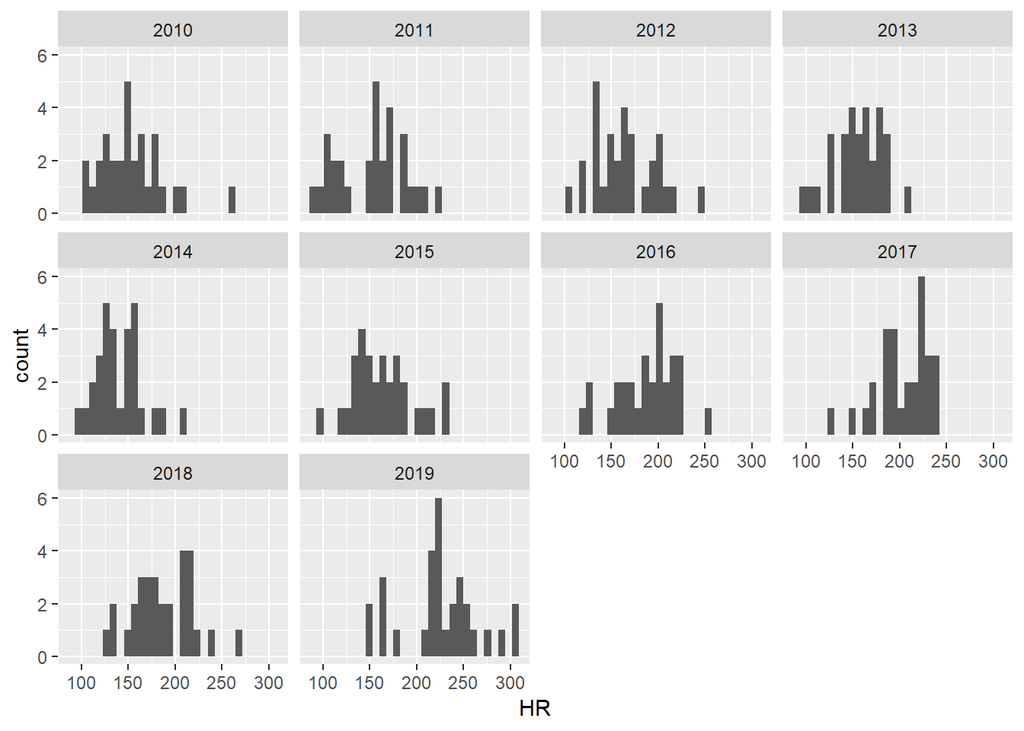

```r
ggplot(season_data)+
  geom_histogram(aes(x = HR))+
  facet_wrap(~Season)
```

Next, we would like to examine swing rates. There is a general sense in baseball that pinch hitters are more likely to swing away. To test this thought, we first need to identify pinch hitters. Note the data does not give this information directly. So, we will use the game information - namely the players currently on the field - to determine when a batter enters the game before being on the field. Since the data does not provide information on the designated hitter, this method will not work for games played in American League ballparks. This should not be a major problem, however, as most pinch hitting happens in the National League anyway. The following code performs the task of identifying pinch hitters and creates an indicator variable “ph.”.

```r
# sort pitches sequentially within each game
pbp_ordered <- pbp2019 %>%
  mutate(game_date = as.Date(game_date, "%m/%d/%Y")) %>%
  arrange(game_date, home_team, inning, desc(inning_topbot), at_bat_number, pitch_number)

# restrict to NL games since no info on DH
nl_games <- pbp_ordered %>%
  filter(home_team %in% c("NYM","WSH","PHI","MIA","ATL",
                          "CHC","CIN","STL","PIT","MIL",
                          "ARI","LAD","SF","COL","SD"))

# determine whether pinch hitter
nl_games$ph <- NA
nl_games_ph <- as.list(nl_games)
for(row in 1:nrow(nl_games)){
  if(nl_games_ph$inning[row] == 1 & nl_games_ph$inning_topbot[row] == "Top"){
    nl_games_ph$ph[row] <- 0
  } else{
    if(nl_games_ph$inning_topbot[row] != nl_games_ph$inning_topbot[row-1]){
      fielders <- list(as.character(nl_games_ph$pitcher.1[row-1]), nl_games_ph$fielder_2.1[row-1],
                       nl_games_ph$fielder_3[row-1] ,nl_games_ph$fielder_4[row-1],
                       nl_games_ph$fielder_5[row-1], nl_games_ph$fielder_6[row-1],
                       nl_games_ph$fielder_7[row-1], nl_games_ph$fielder_8[row-1],
                       nl_games_ph$fielder_9[row-1])
    }
    nl_games_ph$ph[row] <- ifelse(as.character(nl_games_ph$batter[row]) %in% fielders,0,1)
  }
}
nl_games_ph <- as.data.frame(nl_games_ph)
```

To confirm the process works, consider the 6 most common batters among pinch hitters. Remember that the total shown is pitches, not plate appearances.

```r
nl_games_ph %>%
  filter(ph == 1) %>%
  group_by(batter) %>%
  summarize(pitches = n()) %>%
  arrange(desc(pitches)) %>%
  head()
```

```
## # A tibble: 6 x 2
##   batter pitches
##    <int>   <int>
## 1 459964     358
## 2 434158     252
## 3 500874     233
## 4 592122     230
## 5 518586     221
## 6 594824     215
```

The player ids given correspond to Matt Joyce, Curtis Granderson, Jose Martinez, Tyler Austin, Charlie Culberson, and Greg Garcia. All but Martinez were in the top 10 in pinch hitting plate appearances in the regular season, and Martinez had many at bats off the bench in the playoffs, so the total pitches numbers line up. Now, we define an indicator to detect swings.

```r
nl_games_ph_swings <- nl_games_ph %>%
  filter(!(description %in% c("bunt_foul_tip","foul_bunt","missed_bunt",
                              "pitchout","hit_by_pitch"))) %>%
  mutate(swing = ifelse(description %in% c("foul","foul_tip","hit_into_play",
                                           "hit_into_play_no_out","hit_into_play_score"),1,0))
```

Now, we compare swing rates under different situations. Note we will define a few labels for brevity:

first: first pitch of the plate appearance

risp: runners in scoring position

late: in the 7th inning or later

The graph at the end of the section provides a summary of the pinch hitter splits for each category.

```r
# all
nl_games_ph_swings %>%
  group_by(ph) %>%
  summarize(pitches = n(),
            swing_rate = sum(swing) / pitches)
```

```
## # A tibble: 2 x 3
##      ph pitches swing_rate
##   <dbl>   <int>      <dbl>
## 1     0  346125      0.363
## 2     1   20282      0.340
```

```r
# first
nl_games_ph_swings %>%
  filter(pitch_number == 1) %>%
  group_by(ph) %>%
  summarize(pitches = n(),
            swing_rate = sum(swing) / pitches)
```

```
## # A tibble: 2 x 3
##      ph pitches swing_rate
##   <dbl>   <int>      <dbl>
## 1     0   88321      0.230
## 2     1    4968      0.201
```

```r
# risp
nl_games_ph_swings %>%
  filter(on_2b != "null" | on_3b != "null") %>%
  group_by(ph) %>%
  summarize(pitches = n(),
            swing_rate = sum(swing) / pitches)
```

```
## # A tibble: 2 x 3
##      ph pitches swing_rate
##   <dbl>   <int>      <dbl>
## 1     0   78839      0.380
## 2     1    5660      0.351
```

```r
# risp, first
nl_games_ph_swings %>%
  filter(on_2b != "null" | on_3b != "null", pitch_number == 1) %>%
  group_by(ph) %>%
  summarize(pitches = n(),
            swing_rate = sum(swing) / pitches)
```

```
## # A tibble: 2 x 3
##      ph pitches swing_rate
##   <dbl>   <int>      <dbl>
## 1     0   19882      0.266
## 2     1    1354      0.212
```

```r
# late
nl_games_ph_swings %>%
  filter(inning >= 7) %>%
  group_by(ph) %>%
  summarize(pitches = n(),
            swing_rate = sum(swing) / pitches)
```

```
## # A tibble: 2 x 3
##      ph pitches swing_rate
##   <dbl>   <int>      <dbl>
## 1     0  107877      0.362
## 2     1   14536      0.337
```

```r
# risp, late
nl_games_ph_swings %>%
  filter(inning >= 7, on_2b != "null" | on_3b != "null") %>%
  group_by(ph) %>%
  summarize(pitches = n(),
            swing_rate = sum(swing) / pitches)
```

```
## # A tibble: 2 x 3
##      ph pitches swing_rate
##   <dbl>   <int>      <dbl>
## 1     0   24605      0.377
## 2     1    3886      0.344
```

```r
# risp, late, first
nl_games_ph_swings %>%
  filter(inning >= 7, on_2b != "null" | on_3b != "null", pitch_number == 1) %>%
  group_by(ph) %>%
  summarize(pitches = n(),
            swing_rate = sum(swing) / pitches)
```

```
## # A tibble: 2 x 3
##      ph pitches swing_rate
##   <dbl>   <int>      <dbl>
## 1     0    6034      0.263
## 2     1     923      0.206
```

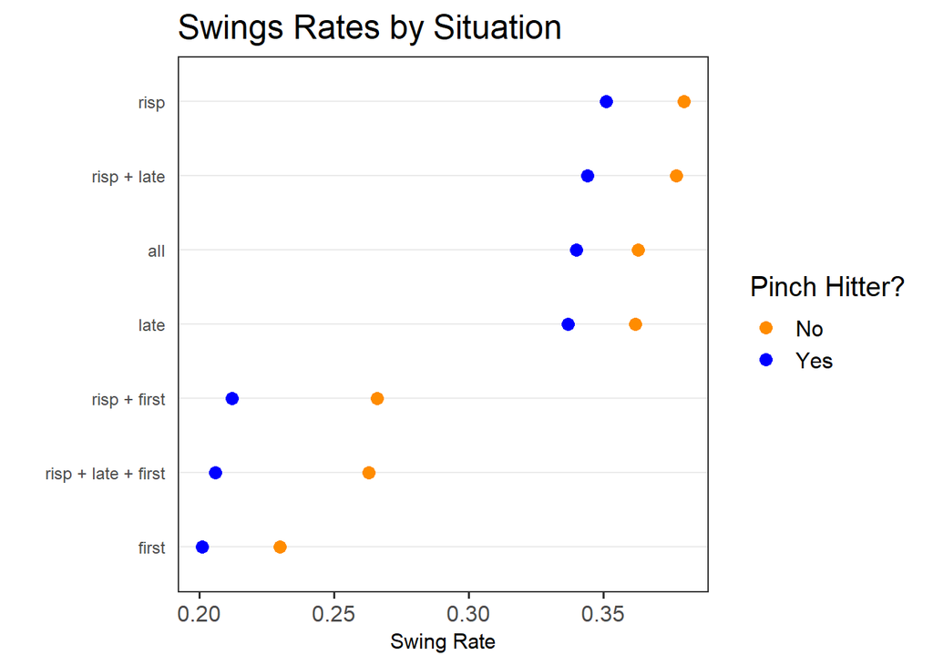

```r
# create data frame with results
df <- data.frame(situation = c("all","all","first","first",
                               "risp","risp","risp + first","risp + first",
                               "late","late","risp + late","risp + late",
                               "risp + late + first","risp + late + first"),
                 ph = factor(c(0,1,0,1,0,1,0,1,0,1,0,1,0,1)),
                 swing_rate = c(.363,.340,.230,.201,.380,.351,.266,.212,
                                .362,.337,.377,.344,.263,.206))

# cleveland dot plot
theme_dotplot <- theme_bw(15) +
  theme(axis.text.y = element_text(size = rel(.75)),
        axis.ticks.y = element_blank(),
        axis.title.x = element_text(size = rel(.75)),
        panel.grid.major.x = element_blank(),
        panel.grid.major.y = element_line(size = 0.5),
        panel.grid.minor.x = element_blank())

ggplot(df, aes(x = swing_rate,
               y = fct_reorder2(situation,
                                ph == "1",
                                swing_rate,
                                .desc = FALSE),
               color = ph)) +
  geom_point(size = 3) +
  labs(title = "Swings Rates by Situation", x = "Swing Rate", y = "", color = "Pinch Hitter?") +
  scale_color_manual(labels = c("No", "Yes"), values = c("darkorange", "blue")) +
  theme_dotplot
```

Surprisingly, in every case the swing rate is lower for pinch hitters. This contradicts the initial theory. Also, the swing rates among categories have the same sorted order, with more swings occuring with runners in scoring position and less swings on the first pitch.

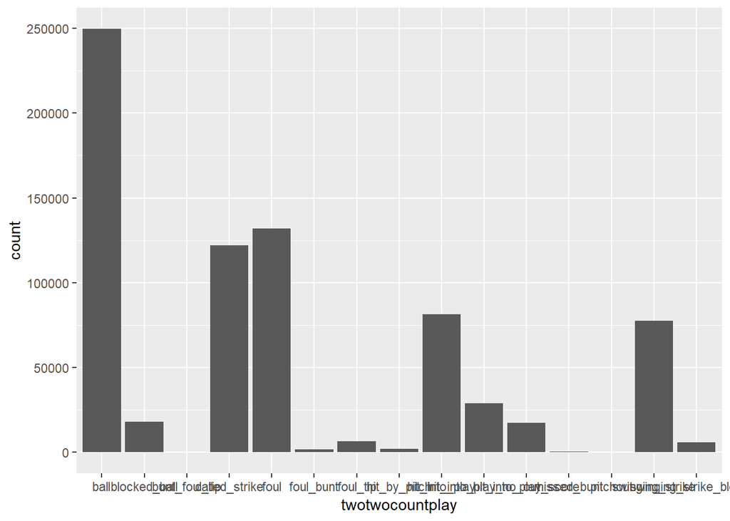

```r
balls <- pbp2019$balls

strikes <- pbp2019$strikes


twotwocount <- pbp2019[strikes && balls == 2,]


twotwocountplay <- twotwocount$description
twotwocountplay1 <- data.frame(twotwocountplay)


ggplot(twotwocountplay1, aes(twotwocountplay))+
  geom_bar()
```